# **Classification d'images sportives**

**Objectif**: Classifier des images dans les catégories suivantes : "baseball", "cricket" et "football".

**Note** : L'utilisation de ce Notebook (et plus particulièrement de l'import des données) nécessite de le placer dans un dossier nommé "Projet apprentissage" à la racine de son Drive, avec les 3 dossiers d'images composant la base de données.

## **1. Configuration de l'environnement de travail**

```python
# !pip uninstall -y Pillow
# !CC="cc -Wno-error=implicit-function-declaration" pip install --no-cache-dir --force-reinstall Pillow
```

```python
from PIL import Image
import os
os.environ["KERAS_BACKEND"] = "torch" # Indique à Keras d'utiliser PyTorch comme backend au lieu de son backend par défaut
```

```python
# Connexion à Google Drive
from google.colab import drive
drive.mount('/content/drive')

# Déplacement du répertoire de travail vers le dossier Drive contenant les données
os.chdir('/content/drive/My Drive/Projet apprentissage')
print("Répertoire actuel :", os.getcwd())
```

```
Répertoire actuel : /content/drive/My Drive/Projet apprentissage
```

## **2. Chargement des données**

```python
def load_data():
    """
    Fonction de chargement des données
    Attention : La librairie pillow doit être installée et s'assurer que le répertoire de travail est celui où se trouve
    la fonction data_loading.py (sans déplacer les sous-dossiers et images)
    """

    labels = []
    images = []

    for dir_files in os.listdir():
        if os.path.isdir(dir_files):
            for img_files in os.listdir('./'+dir_files+'/'):
                if os.path.isfile('./'+dir_files+'/'+img_files):
                    labels.append(dir_files)
                    image = Image.open(dir_files+'/'+img_files)
                    images.append(image)

    return images, labels

print("Lecture des données")
data_images, data_labels = load_data()
print("Données chargées")
```

```
Lecture des données
Données chargées
```

# **3. Préparation des données**

Importations nécessaires pour toute la suite du projet :

```python
import keras

# Préparation des données
import sklearn
from sklearn.model_selection import train_test_split
from sklearn.preprocessing import LabelEncoder

import numpy as np
import matplotlib.pyplot as plt

from keras.datasets import mnist
from keras.utils import to_categorical
#from keras.preprocessing.image import ImageDataGenerator, img_to_array, load_img

# Implémentation des modèles
from keras.models import Sequential
from keras.layers import InputLayer, Dense, Conv2D, MaxPooling2D, Flatten
from keras.applications.resnet50 import ResNet50, preprocess_input, decode_predictions
```

Premier traitement des données :

- Redimensionner, normaliser les données images.
- Convertir les labels en vecteurs (Encodage one-hot)

```python
def prepare_data(data_images,data_labels,target_size):
  resized_images = [image.resize(target_size) for image in data_images]  # Redimensionner les images
  data_images_array = np.array([np.array(image) for image in resized_images])  # Convertir en tableaux
  data_images_array = data_images_array / 255.0  # Normalisation entre 0 et 1

  # Encoder les labels
  label_encoder = LabelEncoder()
  data_labels_encoded = label_encoder.fit_transform(data_labels)
  data_labels_categorical = to_categorical(data_labels_encoded)

  return data_images_array, data_labels_categorical
```

```python
data_images_array, data_labels_cnn = prepare_data(data_images,data_labels,target_size=(64, 64))
print("Dimensions des données :", data_images_array.shape)
```

```
Dimensions des données : (252, 64, 64, 3)
```

### Séparation des données en jeu d'entrainement et de validation

On sépare les données en deux jeux : celui d'entrainement et celui de test. On choisit de garder 30% des données pour la validation du modèle.

```python
X_train, X_test, y_train, y_test=train_test_split(data_images_array, data_labels_cnn, test_size=0.3, train_size=0.7, random_state=None, shuffle=True, stratify=None)
```

## **4. Premier modèle : CNN**

Nous réalisons un premier modèle simple : un réseau neuronal convolutif (CNN) avec 1 couche de convolution.

## Implémentation du modèle

```python
model_1 = Sequential([
    InputLayer(input_shape=(64,64,3)), # 3 canaux (RGB)

    Conv2D(
    filters=100, # nombre de filtres
    kernel_size=(3,3) # taille des filtres
    ),

    MaxPooling2D(pool_size=(2, 2)),

    Flatten(),
    Dense(units=3, activation="softmax")])

model_1.summary()
model_1.compile(optimizer="adam", loss="categorical_crossentropy", metrics=["accuracy"])
m1=model_1.fit(X_train, y_train, validation_data=(X_test, y_test), verbose=2, epochs=20, batch_size=200)
```

```
Model: "sequential_6"
```

```
┏━━━━━━━━━━━━━━━━━━━━━━━━━━━━━━━━━━━━━━┳━━━━━━━━━━━━━━━━━━━━━━━━━━━━━┳━━━━━━━━━━━━━━━━━┓
┃ Layer (type)                         ┃ Output Shape                ┃         Param # ┃
┡━━━━━━━━━━━━━━━━━━━━━━━━━━━━━━━━━━━━━━╇━━━━━━━━━━━━━━━━━━━━━━━━━━━━━╇━━━━━━━━━━━━━━━━━┩
│ conv2d_7 (Conv2D)                    │ (None, 62, 62, 100)         │           2,800 │
├──────────────────────────────────────┼─────────────────────────────┼─────────────────┤
│ max_pooling2d_7 (MaxPooling2D)       │ (None, 31, 31, 100)         │               0 │
├──────────────────────────────────────┼─────────────────────────────┼─────────────────┤
│ flatten_6 (Flatten)                  │ (None, 96100)               │               0 │
├──────────────────────────────────────┼─────────────────────────────┼─────────────────┤
│ dense_8 (Dense)                      │ (None, 3)                   │         288,303 │
└──────────────────────────────────────┴─────────────────────────────┴─────────────────┘
```

```
 Total params: 291,103 (1.11 MB)
```

```
 Trainable params: 291,103 (1.11 MB)
```

```
 Non-trainable params: 0 (0.00 B)
```

```
1/1 - 0s - 64ms/step - accuracy: 0.4148 - loss: 1.1132 - val_accuracy: 0.3026 - val_loss: 9.6198
1/1 - 0s - 63ms/step - accuracy: 0.3182 - loss: 9.1572 - val_accuracy: 0.3026 - val_loss: 3.6706
1/1 - 0s - 63ms/step - accuracy: 0.3182 - loss: 3.2599 - val_accuracy: 0.3553 - val_loss: 4.2390
1/1 - 0s - 59ms/step - accuracy: 0.3977 - loss: 3.8980 - val_accuracy: 0.3947 - val_loss: 3.8909
1/1 - 0s - 80ms/step - accuracy: 0.3920 - loss: 3.9884 - val_accuracy: 0.3947 - val_loss: 3.6481
1/1 - 0s - 81ms/step - accuracy: 0.3750 - loss: 3.6906 - val_accuracy: 0.4474 - val_loss: 2.6559
1/1 - 0s - 106ms/step - accuracy: 0.5227 - loss: 2.4583 - val_accuracy: 0.3684 - val_loss: 1.7327
1/1 - 0s - 78ms/step - accuracy: 0.4489 - loss: 1.3722 - val_accuracy: 0.3158 - val_loss: 2.0533
1/1 - 0s - 63ms/step - accuracy: 0.3409 - loss: 1.7838 - val_accuracy: 0.3026 - val_loss: 2.5578
1/1 - 0s - 63ms/step - accuracy: 0.3295 - loss: 2.3047 - val_accuracy: 0.3026 - val_loss: 1.7671
1/1 - 0s - 62ms/step - accuracy: 0.3693 - loss: 1.5237 - val_accuracy: 0.4605 - val_loss: 1.1183
1/1 - 0s - 64ms/step - accuracy: 0.6761 - loss: 0.8351 - val_accuracy: 0.4737 - val_loss: 1.3506
1/1 - 0s - 64ms/step - accuracy: 0.6420 - loss: 1.0560 - val_accuracy: 0.4868 - val_loss: 1.6055
1/1 - 0s - 67ms/step - accuracy: 0.6193 - loss: 1.3277 - val_accuracy: 0.5000 - val_loss: 1.6721
1/1 - 0s - 63ms/step - accuracy: 0.6307 - loss: 1.3934 - val_accuracy: 0.4868 - val_loss: 1.5813
1/1 - 0s - 61ms/step - accuracy: 0.6307 - loss: 1.2860 - val_accuracy: 0.4342 - val_loss: 1.3923
1/1 - 0s - 241ms/step - accuracy: 0.6420 - loss: 1.0726 - val_accuracy: 0.4737 - val_loss: 1.1809
1/1 - 0s - 175ms/step - accuracy: 0.6705 - loss: 0.8392 - val_accuracy: 0.4605 - val_loss: 1.0480
1/1 - 0s - 62ms/step - accuracy: 0.7955 - loss: 0.6984 - val_accuracy: 0.4605 - val_loss: 1.0673
1/1 - 0s - 60ms/step - accuracy: 0.7500 - loss: 0.7207 - val_accuracy: 0.3553 - val_loss: 1.1684
```

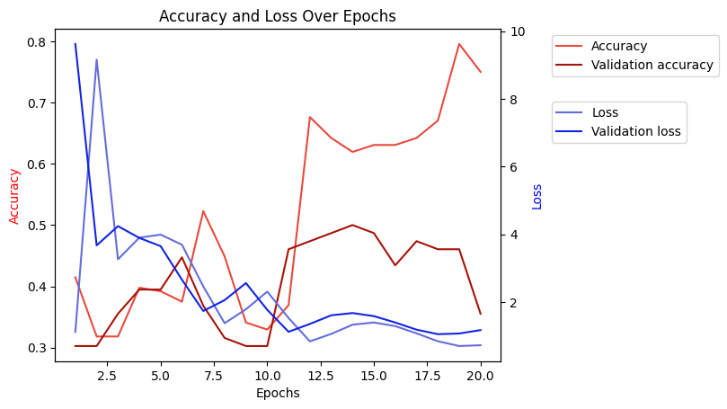

```python
accuracy = m1.history['accuracy']
val_accuracy = m1.history['val_accuracy']
loss = m1.history['loss']
val_loss = m1.history['val_loss']

x = np.arange(1, len(accuracy) + 1)

# Créer la figure et l'axe pour les graphiques
fig, ax1 = plt.subplots()

# Tracer la précision et la précision de validation
ax1.plot(x, accuracy, label='Accuracy', color='#e84a3f')
ax1.plot(x, val_accuracy, label='Validation accuracy', color='#a61308')

# Créer un autre axe pour la perte et la perte de validation
ax2 = ax1.twinx()  # Partage le même axe x mais un axe y séparé
ax2.plot(x, loss, label='Loss', color='#646ed9')
ax2.plot(x, val_loss, label='Validation loss', color='#1224e3')

# Ajouter les légendes
ax1.legend(loc='upper left', bbox_to_anchor=(1.1, 1))
ax2.legend(loc='upper left', bbox_to_anchor=(1.1, 0.8))

# Ajouter des labels et un titre
ax1.set_xlabel('Epochs')
ax1.set_ylabel('Accuracy', color='red')
ax2.set_ylabel('Loss', color='blue')

# Afficher le graphique
plt.title('Accuracy and Loss Over Epochs')
plt.show()
```

Avec ce modèle simple, on obtient une accuracy relativement bonne sur les données d'entrainement autour de 20 epochs environ. Mais l'accuracy sur les données de test stagne puis commence à décroitre. On rencontre donc une situation de surapprentissage. Ce modèle n'assure pas de résultats suffisants sur les données de validation (50% d'accuracy au maximum).

On teste ensuite un modèle plus complet, incluant 2 couches de concolution et 3 couches denses.

```python
model_2 = Sequential([
    InputLayer(input_shape=(64,64,3)), # 3 canaux (couleur)

    Conv2D(filters=6,
           kernel_size=(5,5),
           activation = 'relu'),
    MaxPooling2D(pool_size=(2, 2)), # ou pool_size=2
    Conv2D(filters=16, kernel_size=5, activation = 'relu'),
    MaxPooling2D(pool_size=2),
    Flatten(),
    Dense(units=120, activation="relu"), # nombre de neurones (=nombre à la sortie)
    Dense(units=84, activation="relu"), # relu : peu couteuse à calculer
    Dense(units=3, activation="softmax") # 3 classes, softmax : sorties entre 0 et 1 sont la somme vaut 1
    ])

model_2.summary()
model_2.compile(optimizer="adam", loss="categorical_crossentropy", metrics=["accuracy"])
m2=model_2.fit(X_train, y_train, validation_data=(X_test, y_test), verbose=2, epochs=20, batch_size=200)
```

```
Model: "sequential_8"
```

```
┏━━━━━━━━━━━━━━━━━━━━━━━━━━━━━━━━━━━━━━┳━━━━━━━━━━━━━━━━━━━━━━━━━━━━━┳━━━━━━━━━━━━━━━━━┓
┃ Layer (type)                         ┃ Output Shape                ┃         Param # ┃
┡━━━━━━━━━━━━━━━━━━━━━━━━━━━━━━━━━━━━━━╇━━━━━━━━━━━━━━━━━━━━━━━━━━━━━╇━━━━━━━━━━━━━━━━━┩
│ conv2d_10 (Conv2D)                   │ (None, 60, 60, 6)           │             456 │
├──────────────────────────────────────┼─────────────────────────────┼─────────────────┤
│ max_pooling2d_10 (MaxPooling2D)      │ (None, 30, 30, 6)           │               0 │
├──────────────────────────────────────┼─────────────────────────────┼─────────────────┤
│ conv2d_11 (Conv2D)                   │ (None, 26, 26, 16)          │           2,416 │
├──────────────────────────────────────┼─────────────────────────────┼─────────────────┤
│ max_pooling2d_11 (MaxPooling2D)      │ (None, 13, 13, 16)          │               0 │
├──────────────────────────────────────┼─────────────────────────────┼─────────────────┤
│ flatten_8 (Flatten)                  │ (None, 2704)                │               0 │
├──────────────────────────────────────┼─────────────────────────────┼─────────────────┤
│ dense_12 (Dense)                     │ (None, 120)                 │         324,600 │
├──────────────────────────────────────┼─────────────────────────────┼─────────────────┤
│ dense_13 (Dense)                     │ (None, 84)                  │          10,164 │
├──────────────────────────────────────┼─────────────────────────────┼─────────────────┤
│ dense_14 (Dense)                     │ (None, 3)                   │             255 │
└──────────────────────────────────────┴─────────────────────────────┴─────────────────┘
```

```
 Total params: 337,891 (1.29 MB)
```

```
 Trainable params: 337,891 (1.29 MB)
```

```
 Non-trainable params: 0 (0.00 B)
```

```
1/1 - 0s - 40ms/step - accuracy: 0.3807 - loss: 1.0946 - val_accuracy: 0.3553 - val_loss: 1.1217
1/1 - 0s - 42ms/step - accuracy: 0.4091 - loss: 1.0677 - val_accuracy: 0.3684 - val_loss: 1.0860
1/1 - 0s - 37ms/step - accuracy: 0.5398 - loss: 1.0452 - val_accuracy: 0.4079 - val_loss: 1.0781
1/1 - 0s - 38ms/step - accuracy: 0.6534 - loss: 1.0079 - val_accuracy: 0.3816 - val_loss: 1.0869
1/1 - 0s - 38ms/step - accuracy: 0.5795 - loss: 0.9609 - val_accuracy: 0.3816 - val_loss: 1.0763
1/1 - 0s - 37ms/step - accuracy: 0.6364 - loss: 0.9089 - val_accuracy: 0.4211 - val_loss: 1.0414
1/1 - 0s - 38ms/step - accuracy: 0.7216 - loss: 0.8619 - val_accuracy: 0.4474 - val_loss: 1.0594
1/1 - 0s - 41ms/step - accuracy: 0.6818 - loss: 0.8090 - val_accuracy: 0.4211 - val_loss: 1.1088
1/1 - 0s - 39ms/step - accuracy: 0.6193 - loss: 0.8186 - val_accuracy: 0.4079 - val_loss: 1.1105
1/1 - 0s - 37ms/step - accuracy: 0.5739 - loss: 0.8251 - val_accuracy: 0.4605 - val_loss: 1.0373
1/1 - 0s - 40ms/step - accuracy: 0.7614 - loss: 0.7276 - val_accuracy: 0.4211 - val_loss: 1.1123
1/1 - 0s - 43ms/step - accuracy: 0.6761 - loss: 0.7210 - val_accuracy: 0.4342 - val_loss: 1.1008
1/1 - 0s - 43ms/step - accuracy: 0.7159 - loss: 0.6800 - val_accuracy: 0.5395 - val_loss: 1.0724
1/1 - 0s - 42ms/step - accuracy: 0.7330 - loss: 0.6568 - val_accuracy: 0.4737 - val_loss: 1.0397
1/1 - 0s - 38ms/step - accuracy: 0.8068 - loss: 0.6316 - val_accuracy: 0.4211 - val_loss: 1.0513
1/1 - 0s - 38ms/step - accuracy: 0.8182 - loss: 0.5991 - val_accuracy: 0.4737 - val_loss: 1.0787
1/1 - 0s - 40ms/step - accuracy: 0.8125 - loss: 0.5644 - val_accuracy: 0.4342 - val_loss: 1.1088
1/1 - 0s - 40ms/step - accuracy: 0.8068 - loss: 0.5525 - val_accuracy: 0.4342 - val_loss: 1.0689
1/1 - 0s - 38ms/step - accuracy: 0.8750 - loss: 0.5032 - val_accuracy: 0.4737 - val_loss: 1.0874
1/1 - 0s - 40ms/step - accuracy: 0.8580 - loss: 0.5024 - val_accuracy: 0.4605 - val_loss: 1.0843
```

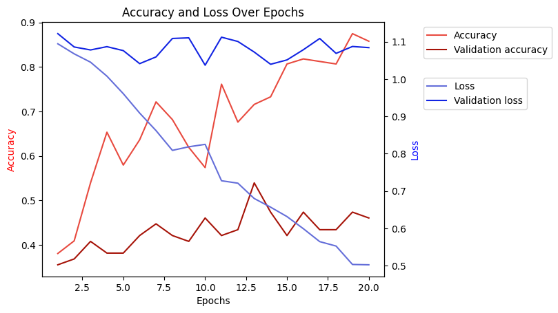

```python
accuracy = m2.history['accuracy']
val_accuracy = m2.history['val_accuracy']
loss = m2.history['loss']
val_loss = m2.history['val_loss']

x = np.arange(1, len(accuracy) + 1)

# Créer la figure et l'axe pour les graphiques
fig, ax1 = plt.subplots()

# Tracer la précision et la précision de validation
ax1.plot(x, accuracy, label='Accuracy', color='#e84a3f')
ax1.plot(x, val_accuracy, label='Validation accuracy', color='#a61308')

# Créer un autre axe pour la loss et la loss de validation
ax2 = ax1.twinx()  # Partage le même axe x mais un axe y séparé
ax2.plot(x, loss, label='Loss', color='#646ed9')
ax2.plot(x, val_loss, label='Validation loss', color='#1224e3')

# Ajouter les légendes
ax1.legend(loc='upper left', bbox_to_anchor=(1.1, 1))
ax2.legend(loc='upper left', bbox_to_anchor=(1.1, 0.8))

# Ajouter des labels et un titre
ax1.set_xlabel('Epochs')
ax1.set_ylabel('Accuracy', color='red')
ax2.set_ylabel('Loss', color='blue')

# Afficher le graphique
plt.title('Accuracy and Loss Over Epochs')
plt.show()
```

Avec ce deuxième modèle, l'accuracy sur les données de validation atteint au maximum 55%, avant chuter. Ces performances restent moyennes.

Nous souhaitons déterminer si l'augmentation d'images permet d'obtenir de meilleurs résultats.

```python
from tensorflow.keras.preprocessing.image import ImageDataGenerator
datagen = ImageDataGenerator(
    rotation_range=20,
    width_shift_range=0.2,
    height_shift_range=0.2,
    shear_range=0.2,
    zoom_range=0.2,
    horizontal_flip=True
)

datagen.fit(X_train)

m2_augmented=model_2.fit(datagen.flow(X_train, y_train, batch_size=200),
            validation_data=(X_test, y_test), epochs=20, verbose=2)
```

```
1/1 - 1s - 1s/step - accuracy: 0.6193 - loss: 0.8626 - val_accuracy: 0.5263 - val_loss: 0.9434
1/1 - 0s - 246ms/step - accuracy: 0.6591 - loss: 0.8095 - val_accuracy: 0.5263 - val_loss: 0.9432
1/1 - 0s - 239ms/step - accuracy: 0.6080 - loss: 0.8203 - val_accuracy: 0.5263 - val_loss: 0.9500
1/1 - 0s - 253ms/step - accuracy: 0.5852 - loss: 0.8236 - val_accuracy: 0.5526 - val_loss: 0.9694
1/1 - 0s - 401ms/step - accuracy: 0.6534 - loss: 0.8010 - val_accuracy: 0.5526 - val_loss: 0.9729
1/1 - 0s - 458ms/step - accuracy: 0.6420 - loss: 0.8021 - val_accuracy: 0.5658 - val_loss: 0.9515
1/1 - 0s - 253ms/step - accuracy: 0.6023 - loss: 0.8327 - val_accuracy: 0.5526 - val_loss: 0.9447
1/1 - 0s - 406ms/step - accuracy: 0.6648 - loss: 0.7764 - val_accuracy: 0.5658 - val_loss: 0.9383
1/1 - 0s - 475ms/step - accuracy: 0.6705 - loss: 0.8135 - val_accuracy: 0.5789 - val_loss: 0.9388
1/1 - 0s - 336ms/step - accuracy: 0.6477 - loss: 0.7981 - val_accuracy: 0.5658 - val_loss: 0.9422
1/1 - 0s - 241ms/step - accuracy: 0.6364 - loss: 0.7844 - val_accuracy: 0.5263 - val_loss: 0.9545
1/1 - 0s - 243ms/step - accuracy: 0.6648 - loss: 0.7410 - val_accuracy: 0.5395 - val_loss: 0.9636
1/1 - 0s - 250ms/step - accuracy: 0.6307 - loss: 0.8132 - val_accuracy: 0.5526 - val_loss: 0.9708
1/1 - 0s - 242ms/step - accuracy: 0.5852 - loss: 0.7992 - val_accuracy: 0.5132 - val_loss: 0.9703
1/1 - 0s - 245ms/step - accuracy: 0.6193 - loss: 0.7708 - val_accuracy: 0.5789 - val_loss: 0.9506
1/1 - 0s - 236ms/step - accuracy: 0.6761 - loss: 0.8001 - val_accuracy: 0.5789 - val_loss: 0.9539
1/1 - 0s - 257ms/step - accuracy: 0.6534 - loss: 0.7374 - val_accuracy: 0.5526 - val_loss: 0.9624
1/1 - 0s - 249ms/step - accuracy: 0.7102 - loss: 0.7189 - val_accuracy: 0.5395 - val_loss: 0.9882
1/1 - 0s - 237ms/step - accuracy: 0.6818 - loss: 0.7353 - val_accuracy: 0.5395 - val_loss: 0.9671
1/1 - 0s - 252ms/step - accuracy: 0.6875 - loss: 0.7129 - val_accuracy: 0.5395 - val_loss: 0.9722
```

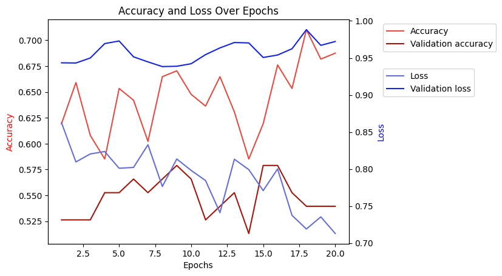

```python
accuracy = m2_augmented.history['accuracy']
val_accuracy = m2_augmented.history['val_accuracy']
loss = m2_augmented.history['loss']
val_loss = m2_augmented.history['val_loss']

x = np.arange(1, len(accuracy) + 1)

# Créer la figure et l'axe pour les graphiques
fig, ax1 = plt.subplots()

# Tracer la précision et la précision de validation
ax1.plot(x, accuracy, label='Accuracy', color='#e84a3f')
ax1.plot(x, val_accuracy, label='Validation accuracy', color='#a61308')

# Créer un autre axe pour la loss et la loss de validation
ax2 = ax1.twinx()  # Partage le même axe x mais un axe y séparé
ax2.plot(x, loss, label='Loss', color='#646ed9')
ax2.plot(x, val_loss, label='Validation loss', color='#1224e3')

# Ajouter les légendes
ax1.legend(loc='upper left', bbox_to_anchor=(1.1, 1))
ax2.legend(loc='upper left', bbox_to_anchor=(1.1, 0.8))

# Ajouter des labels et un titre
ax1.set_xlabel('Epochs')
ax1.set_ylabel('Accuracy', color='red')
ax2.set_ylabel('Loss', color='blue')

# Afficher le graphique
plt.title('Accuracy and Loss Over Epochs')
plt.show()
```

Après l'augmentation des données on n'observe pas de différences significatives dans les performances de ce modèle.

Ainsi, les modèles convolutifs que nous avons testés ne semble pas adaptés pour réaliser cette classification avec un bon taux de réussite. Une des raisons à cela peut être le manque de données sur lesquelles entrainer nos modèles.

Pour cela nous allons par la suite utiliser des modèles pré-entrainés sur des bases de données plus larges.

## **4. Deuxième modèle : ResNet50**

ResNet50 est un CNN pré-entraîné sur un sous ensemble de données issues de ImageNet et contient un total de 1000 classes. Nous retrouvons parmis elle "baseball" et "cricket", mais aucune spécifique au football. Celle qui s'y rapproche le plus est "soccer ball".

Nous testons dans un premier temps le modèle sur nos images.

```python
# Chargement du modèle ResNet50
model_resnet = ResNet50(weights='imagenet')

def prepare_data_resnet(data_images, original_labels):
    # Préparation pour ResNet50 (images redimensionnées à 224x224 et prétraitées)
    resized_images_resnet = [image.resize((224, 224)) for image in data_images]
    data_images_array_resnet = np.array([np.array(image) for image in resized_images_resnet])

    # Appliquer le prétraitement spécifique à ResNet50
    data_images_array_resnet = preprocess_input(data_images_array_resnet)

    # Encoder les labels (seulement si ce n'est pas déjà fait)
    if len(original_labels.shape) == 1:
        label_encoder = LabelEncoder()
        labels_encoded = label_encoder.fit_transform(original_labels)
        labels_categorical = to_categorical(labels_encoded)
    else:
        # Si les labels sont déjà au format categorique, les utiliser tels quels
        labels_categorical = original_labels

    return data_images_array_resnet, labels_categorical

# Utilisation
data_images_resnet, data_labels_resnet = prepare_data_resnet(data_images, data_labels_cnn)

X_train_resnet, X_test_resnet, y_train_resnet, y_test_resnet=train_test_split(data_images_resnet, data_labels_resnet, test_size=0.3, train_size=0.7, random_state=None, shuffle=True, stratify=None)

# Prédictions
x_input = preprocess_input(data_images_resnet)
preds_resnet = model_resnet.predict(x_input)
```

```
8/8 ━━━━━━━━━━━━━━━━━━━━ 2s 330ms/step
```

Nous allons maintenant tester le modèle sur une image choisie aléatoirement dans notre jeu de données, en affichant les 3 classes dont les prédictions sont les plus importantes.

```
1/1 ━━━━━━━━━━━━━━━━━━━━ 0s 205ms/step
```

[figure not shown]

```
Image aléatoire (index 181)
Downloading data from https://storage.googleapis.com/download.tensorflow.org/data/imagenet_class_index.json
35363/35363 ━━━━━━━━━━━━━━━━━━━━ 0s 10us/step
Top 3 prédictions: [('n04254680', 'soccer_ball', 0.2938789), ('n03888257', 'parachute', 0.19646056), ('n04540053', 'volleyball', 0.06916028)]
```

```python
# Générer un index aléatoire
random_index = np.random.randint(0, len(x_input))

# Sélectionner l'image aléatoire
x_input_random = x_input[random_index:random_index+1]

# Faire la prédiction pour cette image
preds_resnet_random = model_resnet.predict(x_input_random)

# Afficher l'image
plt.figure(figsize=(10, 10))
plt.imshow((x_input_random[0] - x_input_random.min()) / (x_input_random.max() - x_input_random.min()))
plt.axis('off')
plt.show()

# Décodage des prédictions
print(f'Image aléatoire (index {random_index})')
print('Top 3 prédictions:', decode_predictions(preds_resnet_random, top=3)[0])
```

Nous observons que le modèle ne classe pas correctement toutes nos images.

**Exemple de bonne prédiction :**

```
Top 3 prédictions: [('n04254680', 'soccer_ball', 0.9608046), ('n04118538', 'rugby_ball', 0.012749683), ('n03445777', 'golf_ball', 0.00995083)]
```

[figure not shown]

```python
%matplotlib inline

# Affichage de l'image n°72 du jeu de données
plt.imshow((x_input[197] - x_input.min()) / (x_input.max() - x_input.min()));

# Top 3 des prédictions sur l'image n°72
print('Top 3 prédictions:', decode_predictions(preds_resnet, top=3)[197])  # Exemple avec la première image
```

**Exemple de mauvaise prédiction :** Sur une image de "baseball", le modèle prédit une racket à 30% et du baseball qu'à 11%.

```
Top 3 prédictions: [('n04039381', 'racket', 0.3046549), ('n02799071', 'baseball', 0.11352258), ('n04254680', 'soccer_ball', 0.08218238)]
```

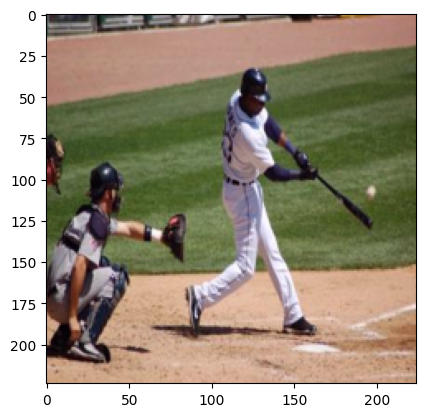

```python
%matplotlib inline

# Affichage de l'image n°72 du jeu de données
plt.imshow((x_input[72] - x_input.min()) / (x_input.max() - x_input.min()));

# Top 3 des prédictions sur l'image n°72
print('Top 3 prédictions:', decode_predictions(preds_resnet, top=3)[72])  # Exemple avec la première image
```

## Ajustement du modèle à nos données

Nous ajustons ce modèle en retirant les couches de sorties pour les remplacer par la couche de classification adaptée à nos classes de sorties.

Nous n'entrainons pas les couches de convolution afin de garder les poids du modèle pré-entrainé.

```python
# Chargement du modèle ResNet50
model_resnet = ResNet50(weights='imagenet',
                      include_top=False, # On retire les couches de sortie
                      input_shape=(224, 224, 3))

# On entraîne pas les couches de convolution
for layer in model_resnet.layers:
  layer.trainable = False


model = Sequential([
    model_resnet,
    Flatten(),
    Dense(units=3, activation='softmax')
    ])

#model.summary()

model.compile(optimizer="adam", loss="categorical_crossentropy", metrics=["accuracy"])
resnet=model.fit(X_train_resnet, y_train_resnet, validation_data=(X_test_resnet, y_test_resnet), epochs=20, batch_size=30)
```

```
6/6 ━━━━━━━━━━━━━━━━━━━━ 3s 496ms/step - accuracy: 0.3327 - loss: 7.5415 - val_accuracy: 0.4079 - val_loss: 9.5436
6/6 ━━━━━━━━━━━━━━━━━━━━ 4s 720ms/step - accuracy: 0.3736 - loss: 10.0803 - val_accuracy: 0.4079 - val_loss: 9.5436
6/6 ━━━━━━━━━━━━━━━━━━━━ 3s 570ms/step - accuracy: 0.4103 - loss: 9.5055 - val_accuracy: 0.4079 - val_loss: 9.5436
6/6 ━━━━━━━━━━━━━━━━━━━━ 3s 579ms/step - accuracy: 0.3728 - loss: 10.0508 - val_accuracy: 0.4342 - val_loss: 9.1194
6/6 ━━━━━━━━━━━━━━━━━━━━ 5s 902ms/step - accuracy: 0.4005 - loss: 9.6291 - val_accuracy: 0.5132 - val_loss: 7.8141
6/6 ━━━━━━━━━━━━━━━━━━━━ 1s 241ms/step - accuracy: 0.4800 - loss: 8.1293 - val_accuracy: 0.6711 - val_loss: 5.0741
6/6 ━━━━━━━━━━━━━━━━━━━━ 3s 564ms/step - accuracy: 0.5565 - loss: 6.5779 - val_accuracy: 0.6579 - val_loss: 5.1464
6/6 ━━━━━━━━━━━━━━━━━━━━ 4s 736ms/step - accuracy: 0.6454 - loss: 5.6583 - val_accuracy: 0.6316 - val_loss: 5.7457
6/6 ━━━━━━━━━━━━━━━━━━━━ 4s 749ms/step - accuracy: 0.6018 - loss: 6.2534 - val_accuracy: 0.5789 - val_loss: 6.1929
6/6 ━━━━━━━━━━━━━━━━━━━━ 1s 247ms/step - accuracy: 0.6621 - loss: 5.3904 - val_accuracy: 0.7105 - val_loss: 4.6620
6/6 ━━━━━━━━━━━━━━━━━━━━ 4s 770ms/step - accuracy: 0.6496 - loss: 5.5780 - val_accuracy: 0.7105 - val_loss: 4.4734
6/6 ━━━━━━━━━━━━━━━━━━━━ 3s 515ms/step - accuracy: 0.6820 - loss: 5.0563 - val_accuracy: 0.6447 - val_loss: 5.4955
6/6 ━━━━━━━━━━━━━━━━━━━━ 4s 689ms/step - accuracy: 0.7163 - loss: 4.2694 - val_accuracy: 0.7895 - val_loss: 3.0736
6/6 ━━━━━━━━━━━━━━━━━━━━ 1s 268ms/step - accuracy: 0.8777 - loss: 1.8368 - val_accuracy: 0.6974 - val_loss: 3.8061
6/6 ━━━━━━━━━━━━━━━━━━━━ 2s 359ms/step - accuracy: 0.8873 - loss: 1.6419 - val_accuracy: 0.8684 - val_loss: 1.9280
6/6 ━━━━━━━━━━━━━━━━━━━━ 2s 307ms/step - accuracy: 0.8632 - loss: 1.8714 - val_accuracy: 0.8816 - val_loss: 1.5327
6/6 ━━━━━━━━━━━━━━━━━━━━ 4s 735ms/step - accuracy: 0.9203 - loss: 1.2021 - val_accuracy: 0.8553 - val_loss: 1.9722
6/6 ━━━━━━━━━━━━━━━━━━━━ 3s 566ms/step - accuracy: 0.9488 - loss: 0.6122 - val_accuracy: 0.8421 - val_loss: 2.1364
6/6 ━━━━━━━━━━━━━━━━━━━━ 2s 317ms/step - accuracy: 0.9704 - loss: 0.4359 - val_accuracy: 0.8816 - val_loss: 1.6524
6/6 ━━━━━━━━━━━━━━━━━━━━ 3s 569ms/step - accuracy: 0.9670 - loss: 0.5312 - val_accuracy: 0.8553 - val_loss: 1.7564
```

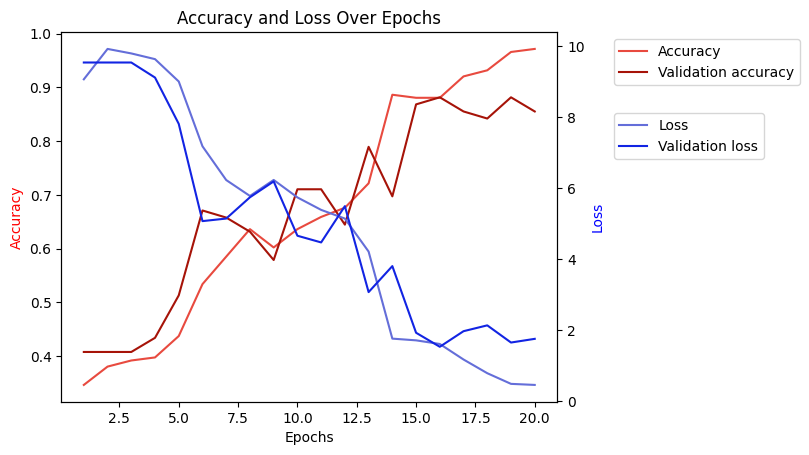

```python
accuracy = resnet.history['accuracy']
val_accuracy = resnet.history['val_accuracy']
loss = resnet.history['loss']
val_loss = resnet.history['val_loss']

x = np.arange(1, len(accuracy) + 1)

# Créer la figure et l'axe pour les graphiques
fig, ax1 = plt.subplots()

# Tracer la précision et la précision de validation
ax1.plot(x, accuracy, label='Accuracy', color='#e84a3f')
ax1.plot(x, val_accuracy, label='Validation accuracy', color='#a61308')

# Créer un autre axe pour la loss et la loss de validation
ax2 = ax1.twinx()  # Partage le même axe x mais un axe y séparé
ax2.plot(x, loss, label='Loss', color='#646ed9')
ax2.plot(x, val_loss, label='Validation loss', color='#1224e3')

# Ajouter les légendes
ax1.legend(loc='upper left', bbox_to_anchor=(1.1, 1))
ax2.legend(loc='upper left', bbox_to_anchor=(1.1, 0.8))

# Ajouter des labels et un titre
ax1.set_xlabel('Epochs')
ax1.set_ylabel('Accuracy', color='red')
ax2.set_ylabel('Loss', color='blue')

# Afficher le graphique
plt.title('Accuracy and Loss Over Epochs')
plt.show()
```

On obtient de bonnes performances avec ce modèle. L'accuracy et la loss de validation stagnent après environ 15 epoch. L'accuracy de validation atteint son maximum à l'epoch n°16 avec 88%.

# Conclusion

Parmi les modèles que nous avons testés, celui obtenant les meilleurs performances est celui adapté à partir du modèle ResNet50. C'est un résultat attendu puisqu'il s'agit d'un modèle pré-entrainé sur une large base de données.

De plus les poids initiaux du modèle permettent d'obtenir de bonnes performances avec un temps d'entrainement relativement court.

Au contraire les premiers modèles que nous avons réalisés sont moins performants, mais ne dépendent pas de données extérieures, et nous offrent un contrôle total sur leur paramétrage.